# 1. **Problem statement**

##### The following report is to explore the relationship between our dependent variable(*median house values*) with other variables. Eventually, this will help us understand how well these factors can predict the housing prices. In detail, we are going to see how *median income, population* & *number of households* impact ***median house value***

```python
import pandas as pd
import matplotlib.pyplot as plt
import seaborn as sns

from sklearn import linear_model
from sklearn.metrics import mean_squared_error, mean_absolute_error
```

# 2. **Getting the Data**

### We can download the [California dataset](https://www.kaggle.com/datasets/camnugent/california-housing-prices?phase=FinishSSORegistration) to load it into our system

```python
housing = pd.read_csv('./data/housing.csv')
```

# 3. **Exploratory Data Analysis (EDA)**

### An approach to analyzing data sets to summarize their main characteristics, often with visual methods.

### 3.1 **Statistics of dataset**

```python
housing.describe()
```

|  | longitude | latitude | housing_median_age | total_rooms | total_bedrooms | population | households | median_income | median_house_value |
| --- | --- | --- | --- | --- | --- | --- | --- | --- | --- |
| count | 20640.000000 | 20640.000000 | 20640.000000 | 20640.000000 | 20433.000000 | 20640.000000 | 20640.000000 | 20640.000000 | 20640.000000 |
| mean | -119.569704 | 35.631861 | 28.639486 | 2635.763081 | 537.870553 | 1425.476744 | 499.539680 | 3.870671 | 206855.816909 |
| std | 2.003532 | 2.135952 | 12.585558 | 2181.615252 | 421.385070 | 1132.462122 | 382.329753 | 1.899822 | 115395.615874 |
| min | -124.350000 | 32.540000 | 1.000000 | 2.000000 | 1.000000 | 3.000000 | 1.000000 | 0.499900 | 14999.000000 |
| 25% | -121.800000 | 33.930000 | 18.000000 | 1447.750000 | 296.000000 | 787.000000 | 280.000000 | 2.563400 | 119600.000000 |
| 50% | -118.490000 | 34.260000 | 29.000000 | 2127.000000 | 435.000000 | 1166.000000 | 409.000000 | 3.534800 | 179700.000000 |
| 75% | -118.010000 | 37.710000 | 37.000000 | 3148.000000 | 647.000000 | 1725.000000 | 605.000000 | 4.743250 | 264725.000000 |
| max | -114.310000 | 41.950000 | 52.000000 | 39320.000000 | 6445.000000 | 35682.000000 | 6082.000000 | 15.000100 | 500001.000000 |

```python
housing.head()
```

|  | longitude | latitude | housing_median_age | total_rooms | total_bedrooms | population | households | median_income | median_house_value | ocean_proximity |
| --- | --- | --- | --- | --- | --- | --- | --- | --- | --- | --- |
| 0 | -122.23 | 37.88 | 41.0 | 880.0 | 129.0 | 322.0 | 126.0 | 8.3252 | 452600.0 | NEAR BAY |
| 1 | -122.22 | 37.86 | 21.0 | 7099.0 | 1106.0 | 2401.0 | 1138.0 | 8.3014 | 358500.0 | NEAR BAY |
| 2 | -122.24 | 37.85 | 52.0 | 1467.0 | 190.0 | 496.0 | 177.0 | 7.2574 | 352100.0 | NEAR BAY |
| 3 | -122.25 | 37.85 | 52.0 | 1274.0 | 235.0 | 558.0 | 219.0 | 5.6431 | 341300.0 | NEAR BAY |
| 4 | -122.25 | 37.85 | 52.0 | 1627.0 | 280.0 | 565.0 | 259.0 | 3.8462 | 342200.0 | NEAR BAY |

# 3.2 **Scatter plot**

#### 1. *median house value* vs *median income*

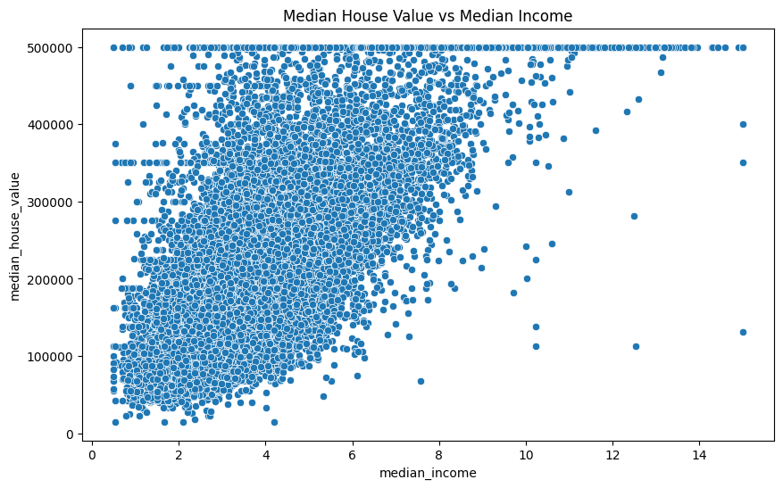

```python
plt.figure(figsize=(10, 6))
sns.scatterplot(x="median_income", y="median_house_value", data= housing)
plt.title("Median House Value vs Median Income")
plt.show()
```

#### Interpretation of *Median House Value* vs *Median Income*:

##### - The scatter plot portrays a strong positive correlation, suggesting higher income levels are associated with higher values of house.

#### 2. *median house value* vs *population*

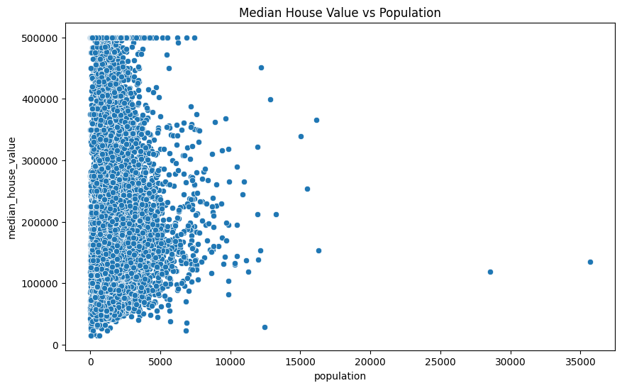

```python
plt.figure(figsize=(10, 6))
sns.scatterplot(x="population", y="median_house_value", data= housing)
plt.title("Median House Value vs Population")
plt.show()
```

#### Interpretation of *Median House Value* vs *Population*:

##### We can witness a variable relationship, since the correlation is weaker and inconsistent.

#### 3. *median house value* vs *number of households*

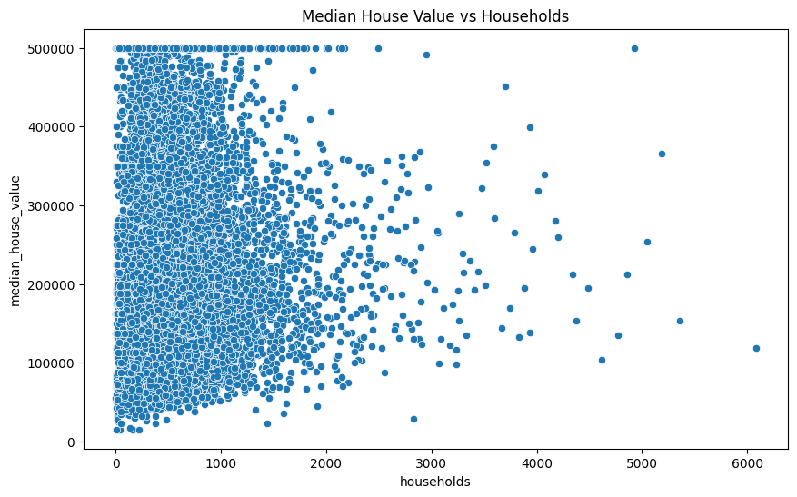

```python
plt.figure(figsize=(10, 6))
sns.scatterplot(x="households", y="median_house_value", data= housing)
plt.title("Median House Value vs Households")
plt.show()
```

#### Interpretation of *Median House Value* vs *Households*:

##### Similarly, the connection appears to be scattered while the lack of clear trend suggests that merely surging of households numbers isn't necessarily correlates with higher home prices.

# 3.3 Description of Variables:

## - Dependent variable

### `median_house_value`: The median value of houses in a given area, appended as dependent variable in our analysis.

## - Independent variable

### `population`: The population represents the total number of residents in a given area, also as independent variable. However, the resultant impact on house values varies as inflation does't correlates with amplifying house property prices.

### `households`: Households indicates the total count of households also as an independent variable which is potentially influenced by housing values.